# Create and apply dictionaries

Phoebe Guinn

14 June 2019

```r
library(ggplot2)
library(stringr)
library(dplyr)
library(tidyverse)
library(quanteda)
library(quanteda.dictionaries)

full_df <- read.table("articlesdf", stringsAsFactors = F)
```

### Cleaning, replacing, removing (or forming dictionary?):

Biases as follows: - Gender specific terms: Mills (2002) also identified the use of terms such as ‘single mum’, ‘working mother’, ‘career woman’ and ‘unmarried mother’ in the media revealing social preconceptions of women. Occupational terms used in relation to women were found to be often premodified by a gender specification such as ‘female lawyer’ and ‘woman judge’, identifying their existence as counter to societal expectations (Sigley and Holmes, 2002). - Use of girl, focus on gender? - Honorific titles - Negative portrayal: appearance, sexuality rather than actions, personal information, personality, health - Use of stereotypes: agressive businesswoman, emotional, homemaker (family relationships and roles), sexual - Narrative structure: Mills (2002) generates a set of questions about a text to ascertain whether a text is gender biased. Are the verbs used concerned with action, with doing, or with reporting feelings or emotions? - Sentiment (Lexicoder) - Adjectives? As part of personality? - The English Regressive Imagery Dictionary (RID), designed by Martindale (1975, 1990), dictionary keys such as “emotions”, “narcissism” contain bags of words typically related to those used in female stereotypes, in particular references to a woman’s appearance and simultaneously usage of adjectives suggesting her to be kind and caring but also emotional and angry.

Creating Address Dictionary keys:

```r
#might need to be removed later
first_names <- c("Angela", "Ann", "Valerie", "Catherine", "Caroline", "Christina", "Clare", "Diane", "Emily", "Estelle", "Harriet", "Hazel", "Helen", "Hilary", "Jacqui", "Janet", "Jo", "Lesley", "Lucy", "Margaret", "Mo", "Marjorie", "Maria", "Mary", "Meg", "Nia", "Pat", "Patricia", "Rachel", "Rebecca", "Rosie", "Ruth", "Sue", "Tessa", "Yvette", "Alan", "Alistair", "Andrew", "Andy", "Ben", "Bob", "Charles", "Chris", "Chuka", "Dan", "David", "Des", "Donald", "Douglas", "Ed", "Frank", "Geoff", "George", "Hilary", "Ivan", "Ivor", "Jack", "James", "Jim", "John", "Jon", "Liam", "Gareth", "Michael", "Nick", "Owen", "Paul", "Peter", "Robin", "Shaun", "Stephen", "Tom", "Tony", "Tristram", "Vernon", "Gaynor")

#Might need to be removed later
last_names <- c("Eagle", "Rayner", "McKechin", "Taylor", "Amos", "Ashton", "Flint", "Rees", "Short", "Abbott", "Thornberry", "Morris", "Harman", "Blears", "Liddell", "Armstrong", "Smith", "Royall", "Platt", "Laird", "Powell", "Beckett", "Curran", "Greenwood", "Jay", "Mowlam", "Creagh", "Hillier", "Griffith", "Glass", "Hewitt", "Reeves", "Long-Bailey", "Winterton", "Kelly", "Hayman", "Jowell", "Vaz", "Cooper", "Johnson", "Milburn", "Darling", "Gwynne", "Burnham", "McDonald", "Bradshaw", "Ainsworth", "Clarke", "Leslie", "Umunna", "Carden", "Blunkett", "Clark", "Miliband", "Browne", "Dewar", "Alexander", "Balls", "Dobson", "Hoon", "Robertson", "Benn", "Lewis", "Richard", "Cunningham", "Straw", "Purnell", "Murphy", "Denham", "Healey", "Hutton", "Prescott", "Reid", "Ashworth", "Trickett", "Byrne", "Adonis", "Williams", "Dugher", "Brown", "Boateng", "Flynn", "Dowd", "Hain", "Mandelson", "Cook", "Woodward", "Byers", "Timms", "Twigg", "Watson", "Lloyd", "Hunt", "Coaker", "Harman's", "Thornberry's", "Darling's", "Eagle's", "Harperson")

#list of job titles/cabinet positions (might need to be removed later)
job_titles <- c("Cabinet", "Minister", "Secretary", "Leader", "House", "Commons", "Lord", "Privy", "Seal", "Lords", "President", "Council", "Office", "Chancellor", "Duchy", "Lancaster", "State", "Social", "Security", "Trade", "Industry", "Business", "Enterprise", "Regulatory", "Reform", "Northern", "Ireland", "Scotland", "International", "Development", "Foreign", "Commonwealth", "Affairs", "Home", "Department", "Work", "ensions", "Health", "Communities", "Local", "Government", "Transport", "Environment", "Food", "Rural", "Culture", "Media", "Sport", "Chief", "Treasury", "Deputy", "Labour", "Party", "Energy", "Climate", "Change", "Whip", "Defence", "Education", "Wales", "Baroness", "Baron", "Lord", "Lady", "Shadow", "Whips", "Chancellor", "Prime")

#General Inquirer
#might need to be removed later
personal_titles <- c("DAME", "DR", "MADAME", "MISS", "MRS ", "MS", "MASTER", "MISTER", "MR", "SIR")
#use following as measure of gender bias
gendered_words <- c("FEMALE", "FEMININE", "GIRL", "WOMAN", "WOMANLY", "WOMEN", "BOY", "GENTLEMAN", "GUY", "MALE", "MAN ", "MANLY", "MASCULINE", "MEN ")
relations <- c("AUNT", "BRIDE", "COUSIN", "DAUGHTER", "GRANDMA", "GRANDMOTHER", "GRANNY", "MOTHER", "MUM", "MUMMY", "NIECE", "SISTER", "WIDOW", "WIFE", "BROTHER", "DAD", "DADDY", "FATHER", "GRANDAD", "GRANDFATHER", "GRANDPA", "GROOM", "HUSBAND", "NEPHEW", "SON", "UNCLE")

#Form dictionary
address_dict <- dictionary(list(fname = first_names, lname = last_names,
                                jtitle = job_titles, ptitle = personal_titles,
                                gendered_words = gendered_words, relations = relations))
```

### Form other dictionaries

Using Lexicoder Sentiment, Harvard General Inquirer (HGI) and English Regressive Imagery (RID) Dictionary: - Sentiment Dictionary - Actions/Political Language Dictionary - Emotions/Feelings Dictionary - Appearance/Personality Dictionary (General Inquirer: http://www.wjh.harvard.edu/~inquirer/homecat.htm)

```r
#Lexicoder
sentdict <- data_dictionary_LSD2015

#ACTIONS
#HGI dictionary: - Strong, Weak, Active, Passive
swapdict_table <- read.csv("~/Capstone/Dictionaries/GI-SWAP.csv",
                            header = T, fill = T, stringsAsFactors = F, na.strings=c("", "NA"))
#remove following words from politics dictionary input
swap_pol <- swapdict_table[,5][!grepl("body|cold|colonial|colony|combat|commissioner|communism|communist|confederate|confederation|congress|congressional|congressman|congressmen|conservatism|conservative|conspiracy|constitution|constitutional|corps|court|courtly|crown|crusade|crusader|delegate|delegation|dictate|dictator|dictatorial|dictatorship|embassy|emperor|empire|enslave|entangle|entanglement|fascist|federal|federation|imperial|imperialist|interstate|invade|iron|junta|jurisdiction|king|kingdom|labor|league|left|legion|lord|loyal|loyalty|mayor|medicare|metropolis|metropolitan|might|ministry|minutemen|power|powerful|precinct|presidency|president|presidential|primary|prince|propaganda|province|queen|radical|rebellious|reds|republic|republican|revolt|revolution|revolutionary|road|royal|royalty|rule|ruler|secede|secession|security|senate|senator|settlement|ship|siege|social|socialism|socialist|sovereign|sovereignty|spokesman|state|statesman|statesmen|surrender|treason|treasonous|tribal|tribe|tyranny|underworld|unimpeachable|usurp|utopia|utopian|vice|villager|war|warlike|white", swapdict_table[,5], ignore.case = T)]

GI_swapdict <- dictionary(list(
  strong = na.omit(swapdict_table[,1]),
  weak = na.omit(swapdict_table[,2]),
  active = na.omit(swapdict_table[,3]),
  passive = na.omit(swapdict_table[,4]),
  politics = na.omit(swap_pol)
  ))

#EMOTIONS/FEELINGS
#HGI general emotions, and 4 categories from RID (some words removed which didn't tend to capture what was required)

emotFeeldict_table <- read.csv("~/Capstone/Dictionaries/GI-emotFeel.csv",
                            header = T, fill = T, stringsAsFactors = F, na.strings=c("", "NA"))

emot_feel_dict <- dictionary(list(
  RID_em_anxiety = data_dictionary_RID$EMOTIONS$ANXIETY,
  RID_em_sadness = data_dictionary_RID$EMOTIONS$SADNESS[!grepl("orphan*", data_dictionary_RID$EMOTIONS$SADNESS)],
  RID_em_affection = data_dictionary_RID$EMOTIONS$AFFECTION[!grepl("marriag*|marri*|bridal*|bride*|fianc*|fraternity*|mating*|romanc*|sweetheart*|wooed*|wooing*|woos",data_dictionary_RID$EMOTIONS$AFFECTION)],
  RID_em_aggression = data_dictionary_RID$EMOTIONS$AGGRESSION[!grepl("army*|arrow*|assault*|attack*|football*|weapon*|whip*|wars|warrior*|tortur*|shoot*|shot*|injury*|kill*|knif*|gun|gunn*|guns|homicid*|murder*|blade*|bloody*|beaten*|maim*|stab*|strangl*|sword*|war*|ax|axe|axes|bloody*|hit|hits|hitt*|kick*|protest*|rapin*|rip*|ripp*|rips|rob|robb*|robs|seiz*|slander*|slap*|slaughter*|steal*|stol*|stolen*|strik*|violenc*|violent*|wound*|abus*|abusiv*|broken*|brok*|mock*|tyrant*|trachery*|vengeanc*|trampl",data_dictionary_RID$EMOTIONS$AGGRESSION)],
  GID_em = na.omit(emotFeeldict_table[,1])
))


#APPEARANCE/PERSONALITY/SEXUAL
#HGI used for personality (adjectives), RID used for body, clothing formed as a mixture of theoretical and empirical reasoning
appeardict_table <- read.csv("~/Capstone/Dictionaries/personality_apparel.csv",
                            header = T, fill = T, stringsAsFactors = F, na.strings=c("", "NA"))

# edit apparel key, since tended to capture news story rather than describe politician
appear_body <- appeardict_table[,3][!grepl("cap?|gown|veil|wetsuit|fedora|helmet|briefs|boot?|vest|uniform?|ring?|skirt|bow|purse|bikini?|heels|pants",appeardict_table[,3])]
appear_body <- c(appear_body, "boots")


appear_person_dict <- dictionary(list(
  RID_body = gsub("\\*", "\\?", data_dictionary_RID$PRIMARY$REGR_KNOL$NARCISSISM)[!grepl("chin*|arms|hand*|face|blood*|brain*|corps*|facies|heart*|kidney*|liver*|organ*|skull*|vein*|thumb*|bone*|skin*|head*|ribs|heel*|hip|toe|toes|forehead*|flesh*|eye*|cheek*)",data_dictionary_RID$PRIMARY$REGR_KNOL$NARCISSISM )],
  apparel = na.omit(appear_body),
  GI_IndAdj = na.omit(appeardict_table[,1][!grepl("HACKNEY", appeardict_table[,1])]),
  GI_IPAdj = na.omit(appeardict_table[,2])
))

#remove tables
rm(emotFeeldict_table, swapdict_table, appeardict_table)
```

Apply dictionaries to full corpus, grouped by gender and topic:

```r
#create corpus
full_corp <- corpus(full_df$Article)
docvars(full_corp, "gender") <- full_df$gender
docvars(full_corp, "topic") <- full_df$topic
#create dfm, grouped by topic and gender
full_dfm <- dfm(full_corp, groups = c("gender", "topic"), tolower = T, remove_punct = T,
                remove = c(stopwords("english"), "GETTY", first_names, last_names)) %>%
  dfm_trim(min_termfreq = 10) %>%
  dfm_weight(scheme = "prop")

#NB. job_titles, personal_titles, first_names and last_names removed first just in case any of the other dictionaries contained words/polysemes that coincided items in these keys.

sentiment <- dfm_remove(full_dfm, c(job_titles, personal_titles)) %>%
  dfm_lookup(dictionary = sentdict, valuetype = "glob")

address <- dfm_lookup(full_dfm, dictionary = address_dict, valuetype = "glob")

swap <- dfm_remove(full_dfm, c(job_titles, personal_titles)) %>%
  dfm_lookup(dictionary = GI_swapdict, valuetype = "glob")

emotions <- dfm_remove(full_dfm, c(job_titles, personal_titles)) %>%
  dfm_lookup(dictionary = emot_feel_dict, valuetype = "glob")

#join emotions and actions, so can later measure emotionality versus action-based lexicon
emotact <- dfm_remove(full_dfm, c(job_titles, personal_titles)) %>%
  dfm_lookup(dictionary = dictionary(c(as.list(emot_feel_dict), as.list(GI_swapdict))),
             valuetype = "glob")
#emotions-actions
emotact_sum <- as.data.frame(rowSums(emotact[,1:5])-rowSums(emotact[,c(8:10)]))

appearance <- dfm_remove(full_dfm, c(job_titles, personal_titles)) %>%
  dfm_lookup(dictionary = appear_person_dict, valuetype = "glob")
```

Plotting graphs:

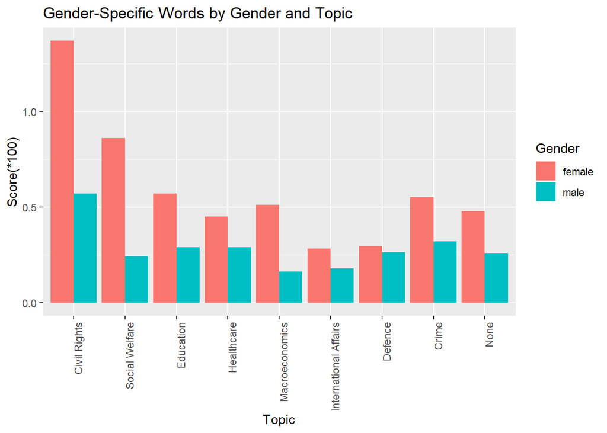

```r
#---------------Address---------------------------------------------------------------
#Good results for gendered_words, relations and personal_titles
#Address Score (gendered words and relations)
#ptitle: follows expected pattern apart from crime (perhaps because many stories by mostly male perpetrators)
address_for_graph <- convert(address, to = "data.frame")
address_for_graph$gender <- str_extract(address_for_graph$document, "(.*)\\.") %>%
  gsub("\\.", "", .)
address_for_graph$topic <- str_extract(address_for_graph$document, "\\.(.*)") %>%
  gsub("\\.", "", .)

#Graphs
address_for_graph %>%
  mutate(topic = fct_relevel(topic, "civil_rights", "social_welfare", "education", "healthcare",
                             "macroeconomics", "intl_affairs", "defence", "crime", "None")) %>%
  ggplot(aes(fill = gender, y=(gendered_words)*100, x = topic)) +
  geom_bar(position="dodge", stat="identity") +
  ggtitle("Gender-Specific Words by Gender and Topic") +
  labs(fill="Gender") +
  ylab("Score(*100)") + xlab("Topic") +
  theme(axis.text.x = element_text(angle=90, hjust=1)) +
  scale_x_discrete(labels=c("Civil Rights","Social Welfare","Education","Healthcare","Macroeconomics",
                            "International Affairs","Defence","Crime","None"))
```

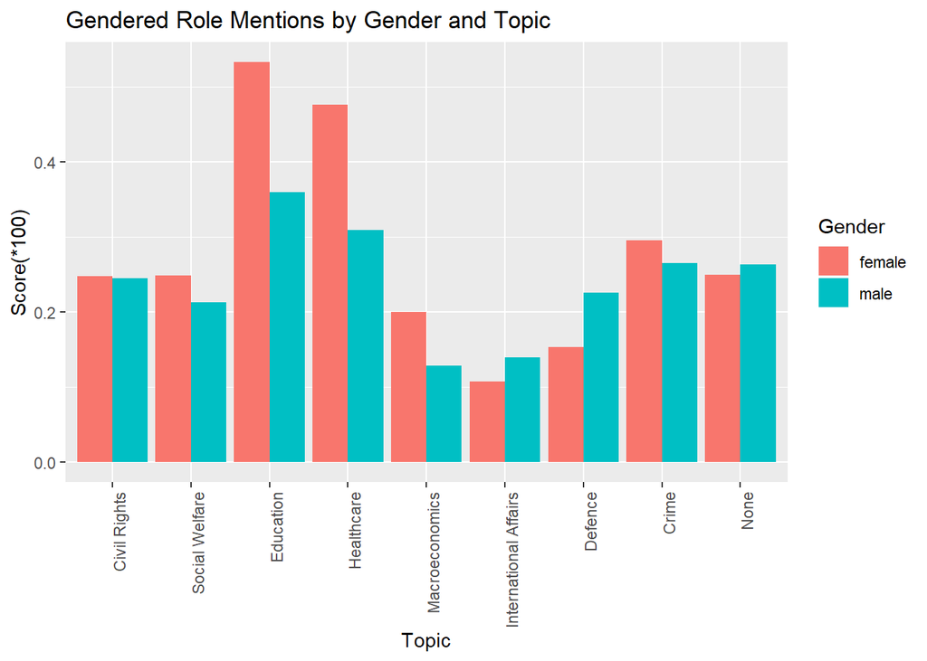

```r
address_for_graph %>%
  mutate(topic = fct_relevel(topic, "civil_rights", "social_welfare", "education", "healthcare",
                             "macroeconomics", "intl_affairs", "defence", "crime", "None")) %>%
  ggplot(aes(fill = gender, y=(relations)*100, x = topic)) +
  geom_bar(position="dodge", stat="identity") +
  ggtitle("Gendered Role Mentions by Gender and Topic") +
  labs(fill="Gender") +
  ylab("Score(*100)") + xlab("Topic") +
  theme(axis.text.x = element_text(angle=90, hjust=1)) +
  scale_x_discrete(labels=c("Civil Rights","Social Welfare","Education","Healthcare","Macroeconomics",
                            "International Affairs","Defence","Crime","None"))
```

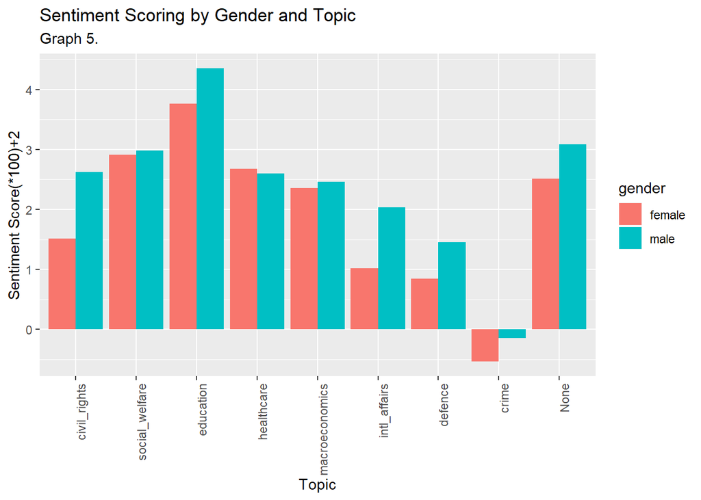

```r
#-----------Sentiment--------------------------------------------------------------------------------
#Sentiment Score
sent_for_graph <- convert(sentiment, to = "data.frame")
sent_for_graph$gender <- str_extract(sent_for_graph$document, "(.*)\\.") %>%
  gsub("\\.", "", .)
sent_for_graph$topic <- str_extract(sent_for_graph$document, "\\.(.*)") %>%
  gsub("\\.", "", .)

#Differences (Male - Female)
sent_for_graph2 <-  as.matrix(filter(sent_for_graph, gender == "male")[,-c(1,6,7)]) -
  as.matrix(filter(sent_for_graph, gender == "female")[,-c(1,6,7)]) %>%
  as.data.frame()
sent_for_graph2$topic <- c("civil_rights", "crime", "defence", "education",
                           "healthcare", "intl_affairs", "macroeconomics", "None", "social_welfare")

#Graph for seperate sentiment
sent_for_graph %>%
  mutate(topic = fct_relevel(topic, "civil_rights", "social_welfare", "education", "healthcare",
                             "macroeconomics", "intl_affairs", "defence", "crime", "None")) %>%
  ggplot(aes(fill= gender, y= ((positive-negative)*100) + 2, x = topic)) +
  geom_bar(position="dodge", stat="identity") +
  ggtitle("Sentiment Scoring by Gender and Topic") +
  ylab("Sentiment Score(*100)+2") + xlab("Topic") + labs(subtitle  = "Graph 5.") +
  theme(axis.text.x = element_text(angle=90, hjust=1))
```

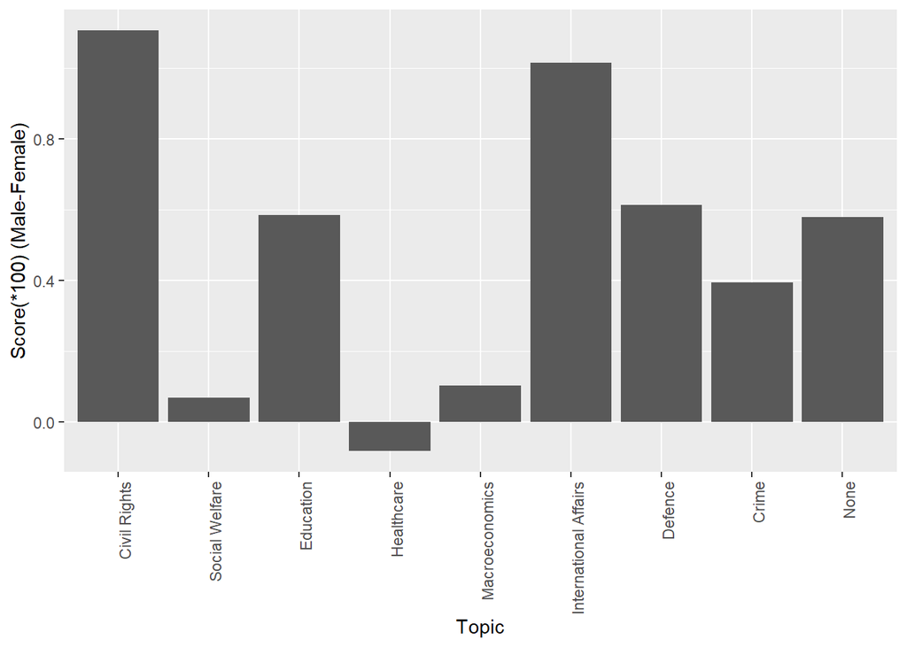

```r
#Differences graph
sent_for_graph2 %>%
  mutate(topic = fct_relevel(topic, "civil_rights", "social_welfare", "education", "healthcare",
                             "macroeconomics", "intl_affairs", "defence", "crime", "None")) %>%
  ggplot(aes(y = ((positive-negative)*100), x = topic)) +
  geom_bar(position="dodge", stat="identity") +
  ylab("Score(*100) (Male-Female)") + xlab("Topic") +
  theme(axis.text.x = element_text(angle=90, hjust=1)) +
  scale_x_discrete(labels=c("Civil Rights","Social Welfare","Education","Healthcare","Macroeconomics",
                            "International Affairs","Defence","Crime","None"))
```

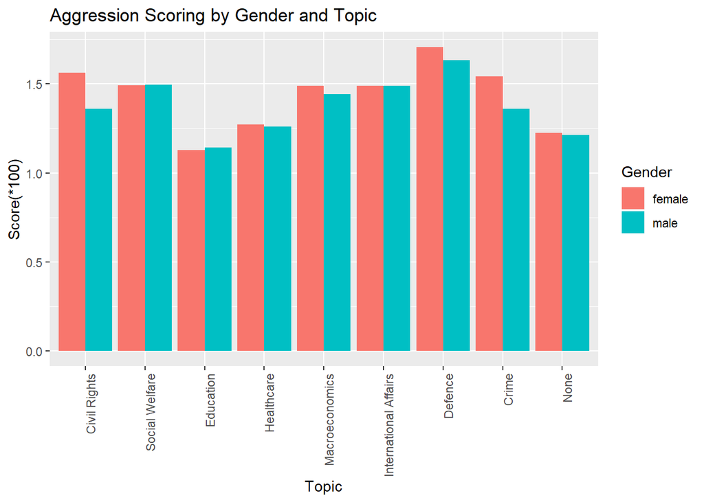

```r
#-----------Strong/Weak-------------------------------------------------------------------------
#Decided not to use strong/active vs weak/passive measure since the items in the dictionaries were varied and nearly all of them were not in reference to the politician, but were in relation to the news story.
#cannon interesting one, in the "strong" category, but used mostly as "loose cannon"

#-------------Emotions/Feelings-----------------------------------------------------------------
#Emotions Score
emot_for_graph <- convert(emotions, to = "data.frame")
emot_for_graph$gender <- str_extract(emot_for_graph$document, "(.*)\\.") %>%
  gsub("\\.", "", .)
emot_for_graph$topic <- str_extract(emot_for_graph$document, "\\.(.*)") %>%
  gsub("\\.", "", .)

#Graph for separate actions
emot_for_graph %>%
  mutate(topic = fct_relevel(topic, "civil_rights", "social_welfare", "education", "healthcare",
                             "macroeconomics", "intl_affairs", "defence", "crime", "None")) %>%
  ggplot(aes(fill = gender, y= (RID_em_aggression)*100, x = topic)) +
  geom_bar(position="dodge", stat="identity") +
  ggtitle("Aggression Scoring by Gender and Topic") +
  labs(fill="Gender") +
  ylab("Score(*100)") + xlab("Topic") +
  theme(axis.text.x = element_text(angle=90, hjust=1)) +
  scale_x_discrete(labels=c("Civil Rights","Social Welfare","Education","Healthcare","Macroeconomics",
                            "International Affairs","Defence","Crime","None"))
```